# Disentangling the drivers of reduced long‐distance seed dispersal by birds in an experimentally fragmented landscape - Uriarte - 2011 - Ecology - Wiley Online Library

### Model construction

Our approach was to use fruit abundance and bird data together with seed retention times to parameterize a mechanistic seed dispersal model with the goal of simulating dispersal for *H. acuminata* in hypothetical landscapes. Here we describe the fitting procedures.

#### Parameter estimation

To quantify the effects of forest fragmentation on bird movement, we developed statistical models that describe perching time between movements, movement length and speed, and movement direction as a function of the habitat that the bird was occupying (primary forest or second-growth matrix), and distance to the nearest habitat boundary in the nearest plant census plot (see *Data collection: Step 1*) (Levey et al. 2005). Habitat and distance to habitat boundary were correlated: birds inside primary forests were generally farther from forest–matrix boundary than birds in the matrix, so we removed distance to the boundary from the analyses. For all variables, we used AIC<sub>c</sub> for model selection (Burnham and Anderson 2002). Following the principle of parsimony, we dropped covariates if the added complexity did not improve the likelihood of the model.

Perch times (in seconds) were initially calculated as the cumulative time that birds remained on a perch without detectable movement by the radio receiver device; perch times were exponentially distributed, *P*(*t*) = 1/λ *e*<sup>[(−*t*/λ)</sup> *<sup>dt</sup>*<sup>]</sup>, where 1/λ is the perch time in seconds. However, birds often changed direction in flight without perching (i.e., sally-gleaning foraging behavior). In our simulations, we needed to account for how these changes in direction might vary in response to habitat variation (e.g., habitat boundary proximity). For this reason, we included these zero values, which led to zero-inflated negative exponential distributions of perching times. We used maximum likelihood estimation to test for effects of habitat type (primary forest vs. secondary growth) and bird species on perch times.

The distance and speed of bird movements between perching points was calculated using Spatial Analyst 3.0 in ArcView 3.2 (ESRI 2000). To avoid biases in path length, we disregarded the distance between the points marked on different days, or when data collection was interrupted by more than 1 hour. Movement distance and speed data were fitted assuming lognormal distributions. We tested for dependence of path length and movement speed on habitat and bird species, both individual species and species guilds, using a generalized linear mixed model with individual as a random effect. *S. turdinus* has traditionally been placed in the manakin family. However, evidence strongly suggests that it is better placed in Tityridae; its body size is in between that of *T. albicollis* and the manakins. For our analyses, we relied on model comparison to assess the grouping for *S. turdinus* that was more consistent with the movement data.

We estimated two metrics of bird movement direction: change in direction between consecutive paths (i.e., turning angles) and path direction relative to the closest habitat boundary between forest and surrounding matrix. We calculated path direction (standard azimuth) and change in direction between consecutive moves as the minimum angular difference (in degrees) between bearings of consecutive paths.

To assess path direction relative to forest–matrix boundary, we used a 2006 Landsat satellite image (30-m resolution). We drew closed-shapes polygons to represent forests and open-shape polygons to represent the matrix, and then estimated bearings for each forest–matrix boundary. Direction of a path to the closest habitat boundary was determined for each path using bearing of the closest forest boundary in the landscape.

A bird's change in primary move direction (μ) could depend on its previous move direction (θ*<sub>t</sub>*<sub>−1</sub>), the bird's response to the habitat boundary, or some combination of both factors. We assessed the relative importance of these factors by testing five possible cases: (1) μ depends only on the previous move direction (i.e., the bird tends to keep traveling in the same direction it has been traveling) (μ = θ<sub>t</sub> − θ*<sub>t</sub>*<sub>−1</sub>); (2) μ is parallel to the nearest habitat boundary (with azimuth α) in a direction consistent with the previous move (i.e., the bird tends to follow along edges μ = θ*<sub>t</sub>* − α); (3) μ is perpendicular to the nearest habitat boundary in a direction consistent with the previous move (the bird tends to cross edges: μ = θ*<sub>t</sub>* − (α + 90)); (4) μ depends on both previous move direction and the nearest habitat boundary, moving parallel to that boundary or edge (a mix of cases 1 and 2, with μ<sub>1</sub> and μ<sub>2</sub> representing cases 1 and 2, respectively):

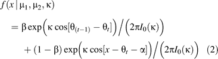

and (5) μ depends on both previous move direction and the nearest habitat boundary, moving perpendicular to that edge (a mix of cases 1 and 3, with μ<sub>1</sub> and μ<sub>2</sub> representing cases 1 and 3):

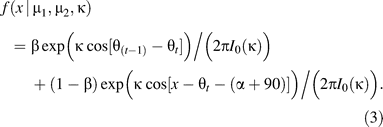

In cases 4 and 5, the movement probability is a weighted average of the direction vectors produced by the two cases being mixed, with the weighting factor β being an estimated parameter ranging from 0 to 1. If β = 1, the mixed case collapses to case 1; if β = 0, the mixed case collapses to either case 2 or case 3.